# ggplot2 Visualizations

Yanwen Wang

10/6/2021

```r
library(tidyverse)
library(ggalt)
library(ggExtra)
library(ggcorrplot)
library(quantmod)
library(scales)
library(gapminder)

# turn-off scientific notation like 1e+48
options(scipen=999)

theme_set(theme_bw())
```

An effective chart is one that:  
1. Conveys the right information without distorting facts.  
2. Is simple but elegant. It should not force you to think much in order to get it.  
3. Aesthetics supports information rather that overshadow it.  
4. Is not overloaded with information.

The list below sorts the visualizations based on its primary purpose. Primarily, there are 8 types of objectives you may construct plots.

# 1 Correlation

## 1.1 Scatterplot

The most frequently used plot for data analysis is undoubtedly the scatterplot. Whenever you want to understand the nature of relationship between two variables, invariably the first choice is the scatterplot.

It can be drawn using `geom_point()`. Additionally, `geom_smooth` which draws a smoothing line (based on loses) by default, can be tweaked to draw the line of best fit by setting `method='lm'`.

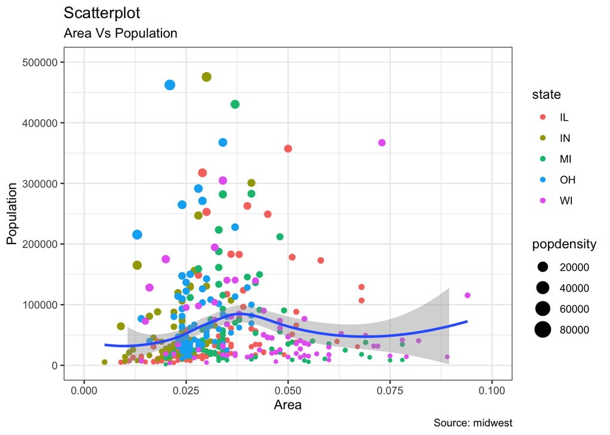

```r
data("midwest", package = "ggplot2")

# Scatterplot
ggplot(midwest, aes(area, poptotal)) +
  geom_point(aes(col = state, size = popdensity)) +
  geom_smooth(formula = y ~ x, method = "loess", se = T) +
  xlim(c(0, 0.1)) +
  ylim(c(0, 500000)) +
  labs(subtitle = "Area Vs Population",
       y = "Population",
       x = "Area",
       title = "Scatterplot",
       caption = "Source: midwest")
```

## 1.2 Scatterplot with Encircling

When presenting the results, sometimes I would encircle certain special group of points or region in the chart so as to draw the attention to those peculiar cases. This can be conveniently done using the `geom_encircle()` in `ggalt` package.

Within `geom_encircle()`, set the data to a new dataframe that contains only the points (rows) or interest. Moreover, You can `expand` the curve so as to pass just outside the points. The `color` and `size` (thickness) of the curve can be modified as well. See below example.

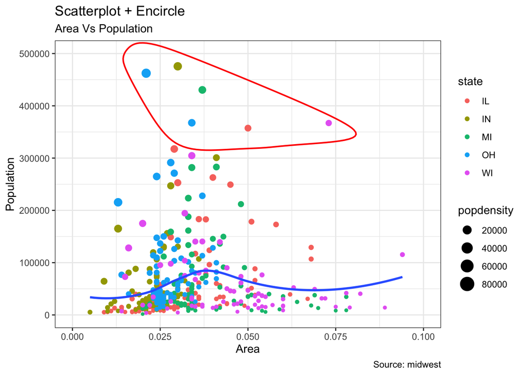

```r
# Select data points to be encircled
midwest_select <- midwest[midwest$poptotal > 350000 &
                            midwest$poptotal <= 500000 &
                            midwest$area > 0.01 &
                            midwest$area < 0.1, ]

ggplot(midwest, aes(area, poptotal)) +
  geom_point(aes(col = state, size = popdensity)) +   # draw points
  geom_smooth(formula = y ~ x, method = "loess", se = F) +
  xlim(c(0, 0.1)) +
  ylim(c(0, 500000)) +
  # draw smoothing line
  geom_encircle(aes(area, poptotal),
                data = midwest_select,
                color = "red",
                size = 2,
                expand = 0.09) +   # encircle
  labs(subtitle = "Area Vs Population",
       y = "Population",
       x = "Area",
       title = "Scatterplot + Encircle",
       caption = "Source: midwest")
```

## 1.3 Jitter Plot

Let’s look at a new data to draw the scatterplot. This time, I will use the `mpg` dataset to plot city mileage (`cty`) vs highway mileage (`hwy`).

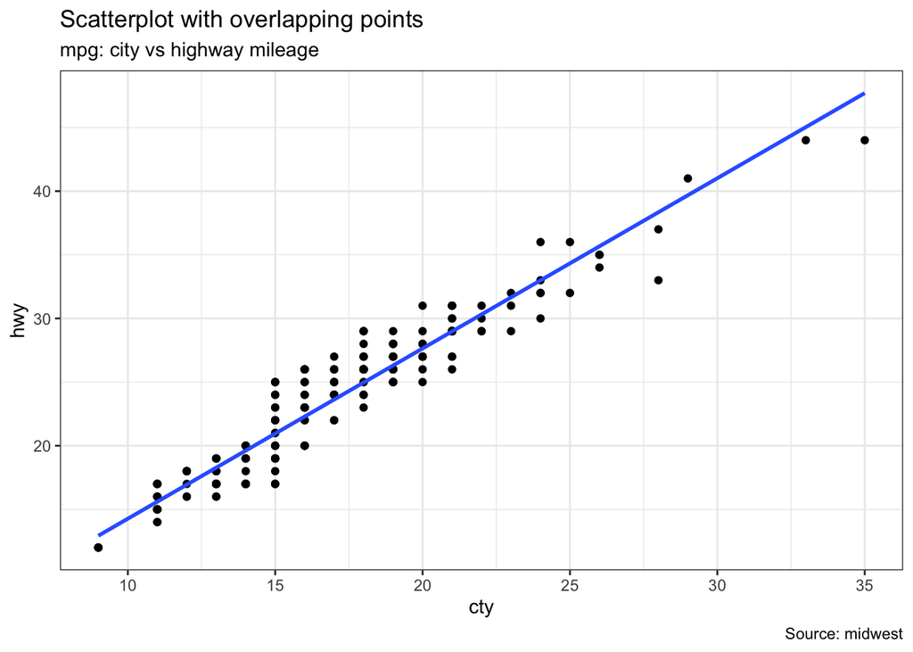

```r
data(mpg, package="ggplot2")

ggplot(mpg, aes(cty, hwy)) +
  geom_point() +
  geom_smooth(formula = y ~ x, method = "lm", se = F) +
  labs(subtitle = "mpg: city vs highway mileage",
       y = "hwy",
       x = "cty",
       title = "Scatterplot with overlapping points",
       caption = "Source: midwest")
```

This innocent looking plot is hiding something. Can you find out?

The original data has 234 data points but the chart seems to display fewer points. What has happened? This is because there are many overlapping points appearing as a single dot.

So how to handle this? There are few options. We can make a jitter plot with `jitter_geom()`. As the name suggests, the overlapping points are randomly jittered around its original position based on a threshold controlled by the width argument.

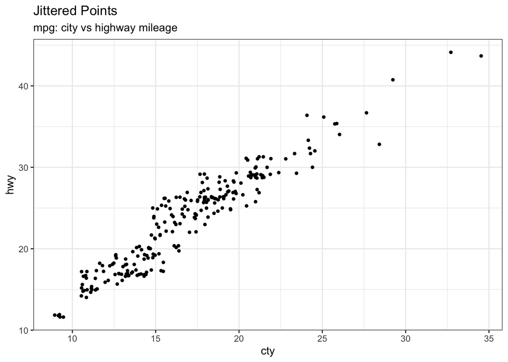

```r
ggplot(mpg, aes(cty, hwy)) +
  geom_jitter(width = .5, size = 1) +
  labs(subtitle = "mpg: city vs highway mileage",
       y = "hwy",
       x = "cty",
       title = "Jittered Points")
```

## 1.4 Counts Chart

The second option to overcome the problem of data points overlap is to use what is called a counts chart. Wherever there is more points overlap, the size of the circle gets bigger.

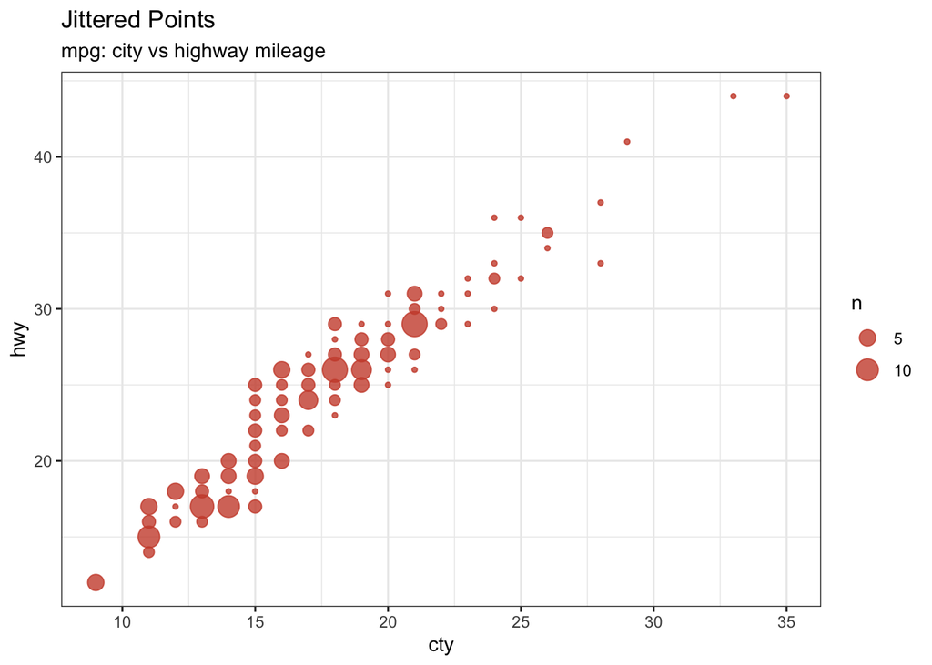

```r
ggplot(mpg, aes(cty, hwy)) +
  geom_count(col = "tomato3", show.legend = T, alpha = 0.8) +
  labs(subtitle = "mpg: city vs highway mileage",
       y = "hwy",
       x = "cty",
       title = "Jittered Points")
```

## 1.5 Bubble Plot

While scatterplot lets you compare the relationship between 2 continuous variables, bubble chart serves well if you want to understand relationship within the underlying groups based on:  
1. A Categorical variable (by changing the color) and  
2. Another continuous variable (by changing the size of points).

In simpler words, bubble charts are more suitable if you have 4-Dimensional data where two of them are numeric (X and Y) and one other categorical (color) and another numeric variable (size).

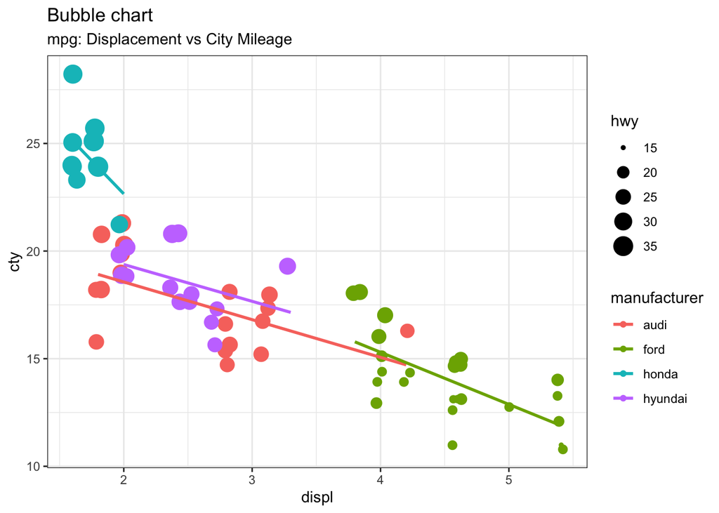

```r
mpg_select <- mpg[mpg$manufacturer %in% c("audi", "ford", "honda", "hyundai"), ]

ggplot(mpg_select, aes(displ, cty)) +
  geom_jitter(aes(col = manufacturer, size = hwy)) +
  geom_smooth(aes(col = manufacturer), formula = y ~ x, method = "lm", se = F) +
  labs(subtitle="mpg: Displacement vs City Mileage",
       title="Bubble chart")
```

## 1.6 Marginal Histogram / Boxplot

If you want to show the relationship as well as the distribution in the same chart, use the marginal histogram. It has a histogram of the X and Y variables at the margins of the scatterplot.

This can be implemented using the `ggMarginal()` function from the `ggExtra` package. Apart from a `histogram`, you could choose to draw a marginal `boxplot` or `density` plot by setting the respective `type` option.

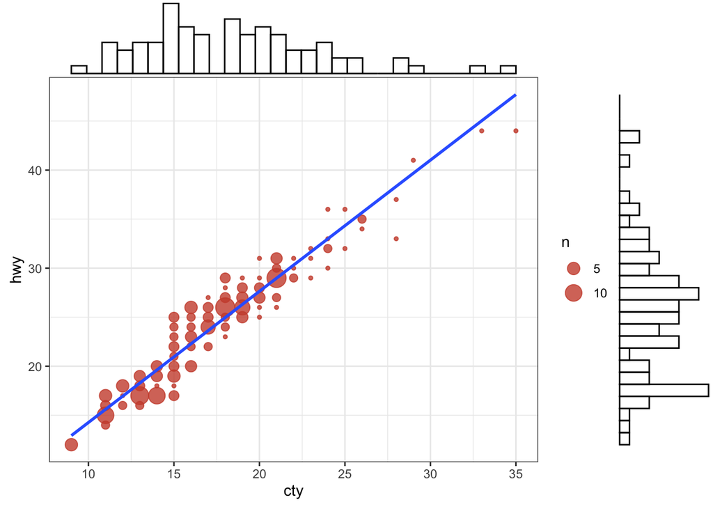

```r
mpg_select <- mpg[mpg$hwy >= 35 & mpg$cty > 27, ]

g <- ggplot(mpg, aes(cty, hwy)) +
  geom_count(col = "tomato3", show.legend = T, alpha = 0.8) +
  geom_smooth(formula = y ~ x, method="lm", se=F)

#ggMarginal(g, type = "boxplot", fill="transparent")
#ggMarginal(g, type = "density", fill="transparent")
ggMarginal(g, type = "histogram", fill="transparent")
```

## 1.7 Correlogram

Correlogram let’s you examine the correlation of multiple continuous variables present in the same dataframe. This is conveniently implemented using the `ggcorrplot` package.

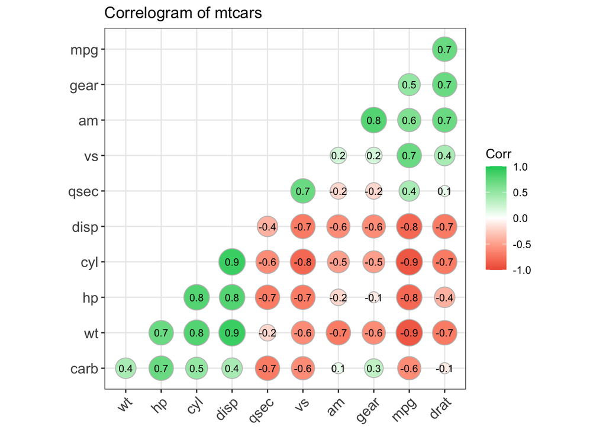

```r
corr <- round(cor(mtcars), 1)

ggcorrplot(corr,
           hc.order = TRUE,
           type = "lower",
           lab = TRUE,
           lab_size = 3,
           method="circle",
           colors = c("tomato2", "white", "springgreen3"),
           title="Correlogram of mtcars",
           ggtheme=theme_bw)
```

# 2 Deviation

## 2.1 Diverging Bars

Diverging Bars is a bar chart that can handle both negative and positive values. This can be implemented by a smart tweak with `geom_bar()`.

By default, `geom_bar()` has the stat set to count. That means, when you provide just a continuous X variable (and no Y variable), it tries to make a histogram out of the data.

In order to make a bar chart create bars instead of histogram, you need to do two things.  
1. Set `stat=identity`  
2. Provide both `x` and `y` inside `aes()` where, `x` is either character or factor and `y` is numeric.

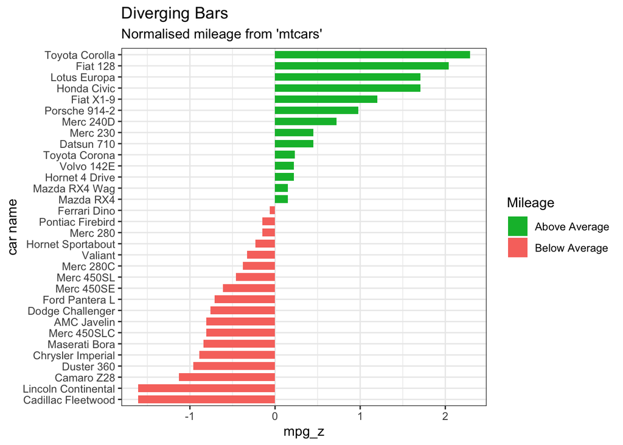

```r
#Create new column for car names
mtcars$`car name` <- rownames(mtcars)
#Compute normalized mpg
mtcars$mpg_z <- round((mtcars$mpg - mean(mtcars$mpg))/sd(mtcars$mpg), 2)
#Above or below avg flag
mtcars$mpg_type <- ifelse(mtcars$mpg_z < 0, "below", "above")
#Sort
mtcars <- mtcars[order(mtcars$mpg_z), ]
#Convert to factor to retain sorted order in plot.
mtcars$`car name` <- factor(mtcars$`car name`, levels = mtcars$`car name`)

#Diverging barcharts
ggplot(mtcars, aes(x = `car name`, y = mpg_z, label = mpg_z)) +
  geom_bar(stat = 'identity', aes(fill = mpg_type), width = 0.7)  +
  scale_fill_manual(name = "Mileage",
                    labels = c("Above Average", "Below Average"),
                    values = c("above"="#00ba38", "below"="#f8766d")) +
  labs(subtitle = "Normalised mileage from 'mtcars'",
       title = "Diverging Bars") +
  coord_flip()
```

## 2.2 Diverging Lollipop Chart

Lollipop chart conveys the same information as bar chart and diverging bar. Except that it looks more modern. Instead of `geom_bar`, I use `geom_point` and `geom_segment` to get the lollipops right. Let’s draw a lollipop using the same data I prepared in the previous example of diverging bars.

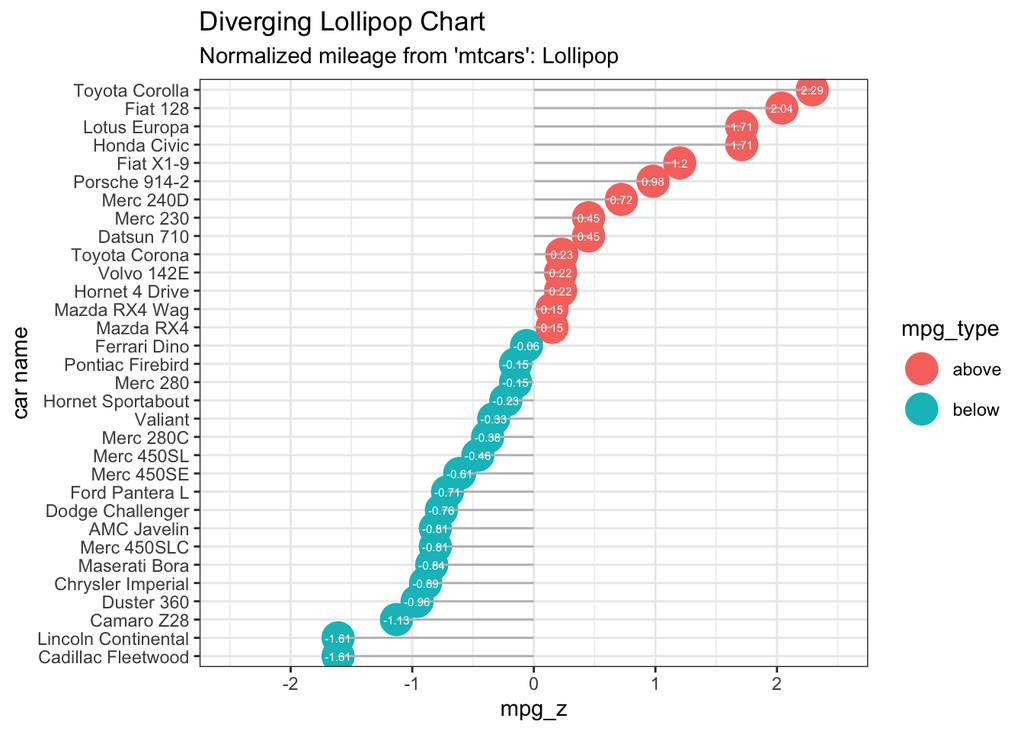

```r
ggplot(mtcars, aes(x = `car name`, y = mpg_z, label = mpg_z)) +
  geom_point(stat = 'identity', aes(col = mpg_type), size = 7)  +
  geom_segment(aes(y = 0,
                   x = `car name`,
                   yend = mpg_z,
                   xend = `car name`),
               color = "grey") +
  geom_text(color = "white", size = 2) +
  labs(title = "Diverging Lollipop Chart",
       subtitle = "Normalized mileage from 'mtcars': Lollipop") +
  ylim(-2.5, 2.5) +
  coord_flip()
```

## 2.3 Area Chart

Area charts are typically used to visualize how a particular metric (such as % returns from a stock) performed compared to a certain baseline. Other types of %returns or %change data are also commonly used. The `geom_area()` implements this.

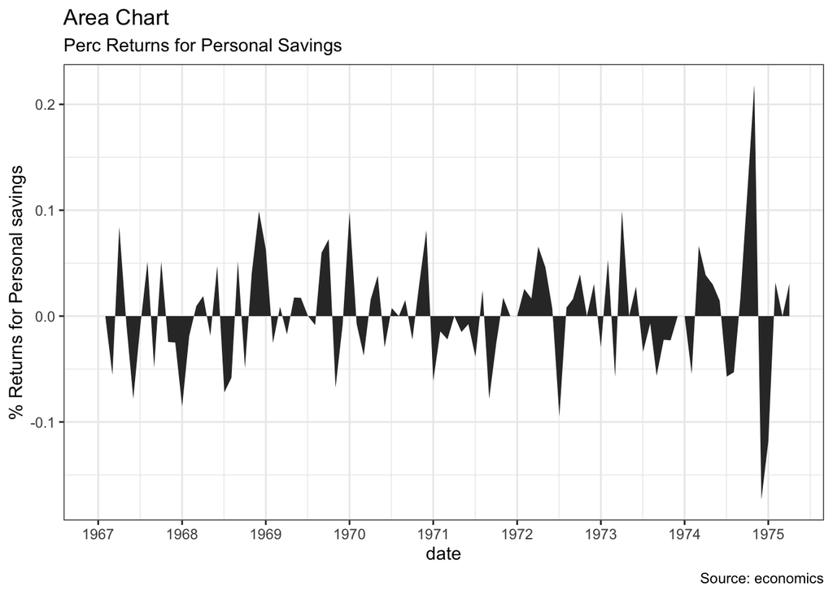

```r
data("economics", package = "ggplot2")

#Compute % Returns
economics$returns_perc <- c(0, diff(economics$psavert)/economics$psavert[-length(economics$psavert)])

# Create break points and labels for axis ticks
brks <- economics$date[seq(1, length(economics$date), 12)]
lbls <- lubridate::year(economics$date[seq(1, length(economics$date), 12)])

ggplot(economics[1:100, ], aes(date, returns_perc)) +
  geom_area() +
  scale_x_date(breaks = brks, labels = lbls) +
  labs(title = "Area Chart",
       subtitle = "Perc Returns for Personal Savings",
       y = "% Returns for Personal savings",
       caption = "Source: economics")
```

# 3 Ranking

Used to compare the position or performance of multiple items with respect to each other. Actual values matters somewhat less than the ranking.

## 3.1 Ordered Bar Chart

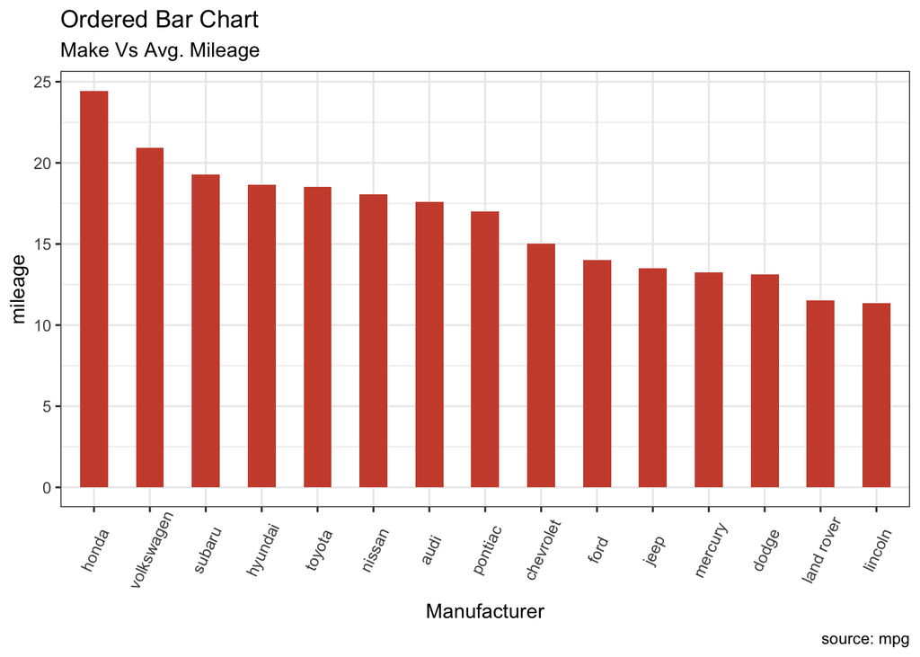

```r
mpg %>%
  group_by(manufacturer) %>%
  summarise(mileage = mean(cty)) %>%

  ggplot(aes(reorder(manufacturer, -mileage), mileage)) +
    geom_bar(stat = "identity", width = 0.5, fill = "tomato3") +
    labs(title = "Ordered Bar Chart",
         subtitle = "Make Vs Avg. Mileage",
         x = "Manufacturer",
         caption = "source: mpg") +
  theme(axis.text.x = element_text(angle=65, vjust=0.6))
```

## 3.2 Lollipop Chart

Lollipop chart reduces the clutter and lays more emphasis on the value.

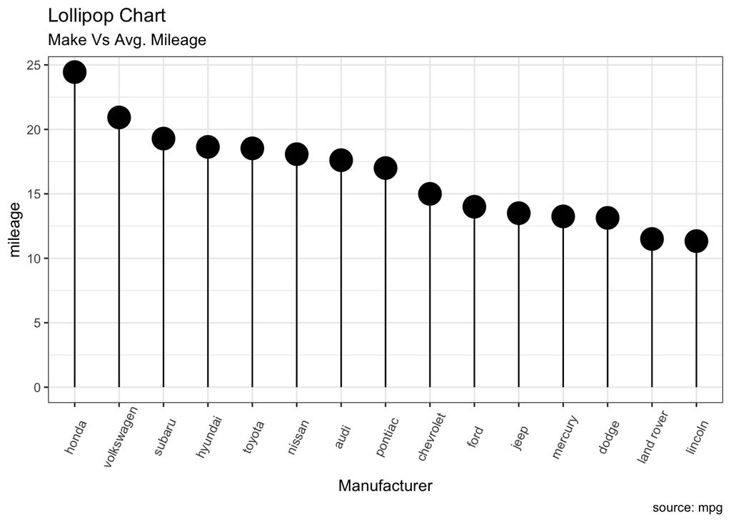

```r
mpg %>%
  group_by(manufacturer) %>%
  summarise(mileage = mean(cty)) %>%

  ggplot(aes(reorder(manufacturer, -mileage), mileage)) +
    geom_point(size = 7) +
    geom_segment(aes(x = manufacturer,
                     xend = manufacturer,
                     y = 0,
                     yend = mileage)) +
    labs(title = "Lollipop Chart",
         subtitle = "Make Vs Avg. Mileage",
         x = "Manufacturer",
         caption = "source: mpg") +
    theme(axis.text.x = element_text(angle=65, vjust=0.6))
```

## 3.3 Dot Plot

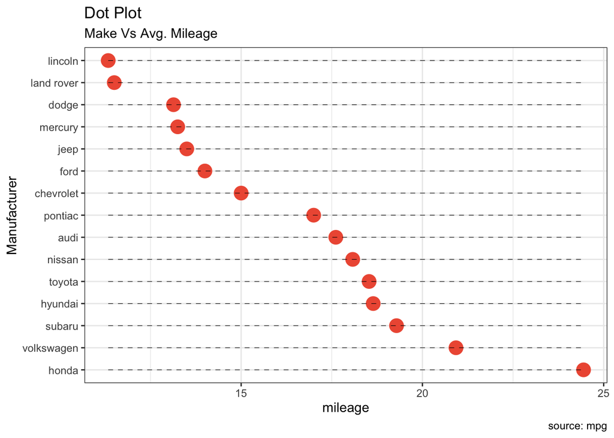

```r
mpg %>%
  group_by(manufacturer) %>%
  summarise(mileage = mean(cty)) %>%

  ggplot(aes(reorder(manufacturer, -mileage), mileage)) +
    geom_point(col="tomato2", size=5) +
    geom_segment(aes(x = manufacturer,
                     xend = manufacturer,
                     y = min(mileage),
                     yend = max(mileage)),
                 linetype="dashed",
                 size=0.2) +
    labs(title = "Dot Plot",
         subtitle = "Make Vs Avg. Mileage",
         x = "Manufacturer",
         caption="source: mpg") +
    coord_flip()
```

## 3.4 Slope Chart

Slope charts are an excellent way of comparing the positional placements between 2 points on time. At the moment, there is no built-in function to construct this. Following code serves as a pointer about how you may approach this.

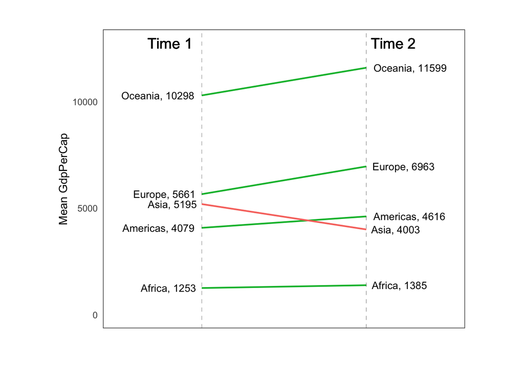

```r
#Prep data
df <- read.csv("https://raw.githubusercontent.com/selva86/datasets/master/gdppercap.csv")

colnames(df) <- c("continent", "1952", "1957")
left_label <- paste(df$continent, round(df$`1952`), sep=", ")
right_label <- paste(df$continent, round(df$`1957`), sep=", ")
df$class <- ifelse((df$`1957` - df$`1952`) < 0, "red", "green")

ggplot(df) +
  geom_segment(aes(x = 1, xend = 2, y = `1952`, yend = `1957`, col = class), size=.75, show.legend=F) +
  geom_vline(xintercept = 1, linetype = "dashed", size = 0.1) +
  geom_vline(xintercept = 2, linetype = "dashed", size = .1) +
  scale_color_manual(labels = c("Up", "Down"),
                     values = c("green"="#00ba38", "red"="#f8766d")) +  # color of lines
  labs(x = "",
       y = "Mean GdpPerCap") +  # Axis labels
  xlim(0.5, 2.5) +
  ylim(0, (1.1 * (max(df$`1952`, df$`1957`)))) +

  geom_text(label=left_label, y=df$`1952`, x=rep(1, NROW(df)), hjust=1.1, size=3.5) +
  geom_text(label=right_label, y=df$`1957`, x=rep(2, NROW(df)), hjust=-0.1, size=3.5) +
  geom_text(label="Time 1", x=1, y=1.1*(max(df$`1952`, df$`1957`)), hjust=1.2, size=5) +  # title
  geom_text(label="Time 2", x=2, y=1.1*(max(df$`1952`, df$`1957`)), hjust=-0.1, size=5) +  # title

  theme(panel.background = element_blank(),
        panel.grid = element_blank(),
        axis.ticks = element_blank(),
        axis.text.x = element_blank(),
        plot.margin = unit(c(1,2,1,2), "cm"))
```

## 3.5 Dumbbell Plot

Dumbbell charts are a great tool if you wish to:  
1. Visualize relative positions (like growth and decline) between two points in time.  
2. Compare distance between two categories.

In order to get the correct ordering of the dumbbells, the Y variable should be a factor and the levels of the factor variable should be in the same order as it should appear in the plot.

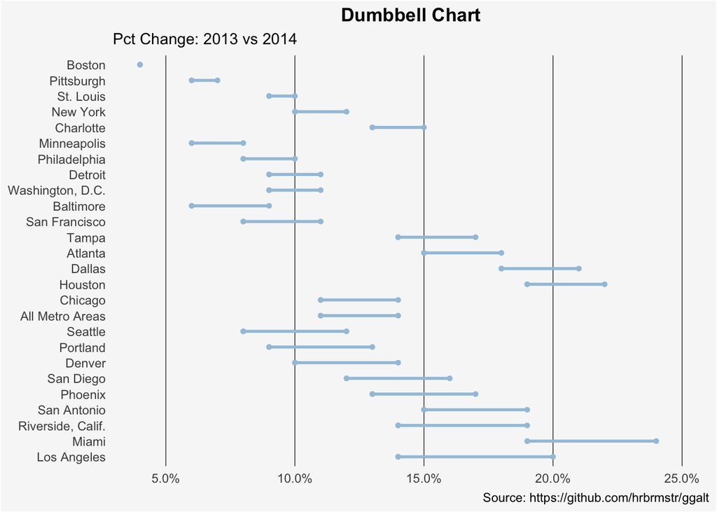

```r
health <- read.csv("https://raw.githubusercontent.com/selva86/datasets/master/health.csv")
health$Area <- factor(health$Area, levels=as.character(health$Area))  # for right ordering of the dumbbells
health$diff <- health$pct_2014 - health$pct_2013

# health$Area <- factor(health$Area)
ggplot(health, aes(x = pct_2013, xend = pct_2014, y = reorder(Area, diff), group = Area)) +
  geom_vline(xintercept = c(0.05, 0.10, 0.15, 0.20, 0.25), size = 0.2) +
  geom_dumbbell(color = "#a3c4dc",
                size = 1,
                point.colour.l = "#0e668b") +
  scale_x_continuous(label=percent) +
  labs(x = NULL,
       y = NULL,
       title = "Dumbbell Chart",
       subtitle = "Pct Change: 2013 vs 2014",
       caption = "Source: https://github.com/hrbrmstr/ggalt") +
  theme(plot.title = element_text(hjust=0.5, face="bold"),
        plot.background=element_rect(fill="#f7f7f7"),
        panel.background=element_rect(fill="#f7f7f7"),
        panel.grid.minor=element_blank(),
        panel.grid.major.y=element_blank(),
        panel.grid.major.x=element_line(),
        axis.ticks=element_blank(),
        legend.position="top",
        panel.border=element_blank())
```

# 4 Distribution

## 4.1 Histogram

## 4.2 Density Plot

## 4.3 Box Plot

## 4.4 Dot + Box Plot

## 4.5 Tufte Boxplot

## 4.6 Violin Plot

## 4.7 Population Pyramid

# 5 Composition

## 5.1 Waffle Chart

## 5.2 Pie Chart

## 5.3 Treemap

## 5.4 Bar Chart

# 6 Change

## 6.1 Time Series Plots

### 6.1.1 From a Data Frame

### 6.1.2 Format to Monthly X Axis

### 6.1.3 Format to Yearly X Axis

### 6.1.4 From Long Data Format

### 6.1.5 From Wide Data Format

## 6.2 Stacked Area Chart

## 6.3 Calendar Heat Map

## 6.4 Slope Chart

## 6.5 Seasonal Plot

# 7 Groups

## 7.1 Dendrogram

## 7.2 Clusters

# 8 Spatial

## 8.1 Open Street Map

## 8.2 Google Road Map

## 8.3 Google Hybrid Map